# Problem Set 1 - Ciencia de los Datos IN5244

Nicolás Delgado Alvarado - 20.224.950-7

# Estadística Descriptiva

## Preliminar

### Instalación de librerías

```r
# Librerías necesarias
#instalar librerias si es que no estan instaladas
if (!requireNamespace("tidyverse", quietly = TRUE)) {install.packages("tidyverse")}
if (!requireNamespace("haven", quietly = TRUE)) {install.packages("haven")}
if (!requireNamespace("janitor", quietly = TRUE)) {install.packages("janitor")}
if (!requireNamespace("skimr", quietly = TRUE)) {install.packages("skimr")}
if (!requireNamespace("ggplot2", quietly = TRUE)) {install.packages("ggplot2")}
if (!requireNamespace("lubridate", quietly = TRUE)) {install.packages("lubridate")}
if (!requireNamespace("gt", quietly = TRUE)) {install.packages("gt")}
if (!requireNamespace("kableExtra", quietly = TRUE)) {install.packages("kableExtra")}
if (!requireNamespace("tibble", quietly = TRUE)) {install.packages("tibble")}
if (!requireNamespace("purrr", quietly = TRUE)) {install.packages("purrr")}
if (!requireNamespace("knitr", quietly = TRUE)) {install.packages("knitr")}
if (!requireNamespace("dplyr", quietly = TRUE)) {install.packages("dplyr")}
if (!requireNamespace("modelsummary", quietly = TRUE)) {install.packages("modelsummary")}
if (!requireNamespace("stargazer", quietly = TRUE)) {install.packages("stargazer")}
if (!requireNamespace("MatchIt", quietly = TRUE)) {install.packages("MatchIt")}
if (!requireNamespace("broom", quietly = TRUE)) {install.packages("broom")}
if (!requireNamespace("AER", quietly = TRUE)) {install.packages("AER")}



library(tidyverse)     # Manipulación y gráficos
library(haven)         # Para leer archivos .dta
library(janitor)       # Limpieza de nombres de columnas
library(skimr)         # Resumen de variables
library(ggplot2)       # Visualización
library(lubridate)     # Manejo de fechas
library(gt)            # Tablas bonitas
library(kableExtra)    # Tablas bonitas
library(tibble)
library(purrr)
library(knitr)
library(dplyr)
library(modelsummary)
library(stargazer)
library(MatchIt)
library(broom)
library(AER)
```

### Configuración de paths

```r
# Define tu ruta local (modifica con tus carpetas)
path_data <- "/data"
path_output <- "/output"

# Crear carpeta si no existe
path_output <- "output"
if (!dir.exists(path_output)) dir.create(path_output, recursive = TRUE)

# Función para guardar gráficos
guardar_plot <- function(plot_obj, nombre_archivo, ancho = 7, alto = 5) {
  ggsave(filename = file.path(path_output, nombre_archivo),
         plot = plot_obj, width = ancho, height = alto)
}

# Función para guardar tablas como CSV
guardar_tabla_csv <- function(tabla, nombre_archivo) {
  write.csv(tabla, file = file.path(path_output, nombre_archivo), row.names = FALSE)
}
```

### Cargar base de datos

```r
# Cargar base de datos .dta
dropout <- casestudy_dropout <- read_dta("data/casestudy_dropout.dta")
```

```r
# Resumen con skimr
resumen_skim <- skim(dropout)

# Mostrar en el documento
print(resumen_skim)
```

```
## ── Data Summary ────────────────────────
##                            Values
## Name                       dropout
## Number of rows             8516
## Number of columns          19
## _______________________
## Column type frequency:
##   Date                     1
##   numeric                  18
## ________________________
## Group variables            None
##
## ── Variable type: Date ─────────────────────────────────────────────────────────
##   skim_variable n_missing complete_rate min        max        median
## 1 DropoutDate           0             1 2022-04-18 2022-07-29 2022-05-26
##   n_unique
## 1       61
##
## ── Variable type: numeric ──────────────────────────────────────────────────────
##    skim_variable           n_missing complete_rate      mean       sd  p0    p25
##  1 IDstudent                       0         1      4258.    2459.      1 2130.
##  2 IDschool                        0         1     11083.    8751.      1 4450
##  3 SchoolGrade2022                 0         1         7.40     3.15    1    5
##  4 DayOfWeekDroppedOut             0         1         2.89     1.41    1    2
##  5 PrioritaryStudentIn2021         0         1         0.647    0.478   0    0
##  6 Female                          0         1         0.531    0.499   0    0
##  7 Age                             0         1        12.1      3.46    6    9
##  8 GPAin2021                     100         0.988     5.51     1.02    1    4.9
##  9 AttendanceIn2021                0         1        82.9     22.2     0   85
## 10 GraduatedIn2021                 0         1         0.907    0.290   0    1
## 11 Migrant                         0         1         0.117    0.322   0    0
## 12 ListedInDropoutReport           0         1         0.182    0.386   0    0
## 13 SchoolPrincipalADP              0         1         0.446    0.497   0    0
## 14 EnrolledByAug312022             0         1         0.788    0.409   0    1
## 15 GraduatedIn2022                 0         1         0.692    0.462   0    0
## 16 MunicipalSchool                 0         1         0.539    0.499   0    0
## 17 SchoolDaysFromMay302022         0         1         0.610   18.7   -30  -17
## 18 DroppedOutMay30Before           0         1         0.541    0.498   0    0
##       p50     p75  p100 hist
##  1 4258.   6387.   8516 ▇▇▇▇▇
##  2 9698.  14676   42061 ▇▇▂▂▁
##  3    8      10      12 ▅▃▃▆▇
##  4    3       4       5 ▇▇▇▇▆
##  5    1       1       1 ▅▁▁▁▇
##  6    1       1       1 ▇▁▁▁▇
##  7   13      15      19 ▆▅▅▇▂
##  8    5.6     6.3     7 ▁▁▂▇▇
##  9   86      96     100 ▁▁▁▁▇
## 10    1       1       1 ▁▁▁▁▇
## 11    0       0       1 ▇▁▁▁▁
## 12    0       0       1 ▇▁▁▁▂
## 13    0       1       1 ▇▁▁▁▆
## 14    1       1       1 ▂▁▁▁▇
## 15    1       1       1 ▃▁▁▁▇
## 16    1       1       1 ▇▁▁▁▇
## 17    2      17      30 ▇▅▆▆▇
## 18    1       1       1 ▇▁▁▁▇
```

```r
# Exportar como CSV (versión simplificada del skim para lectura externa)
guardar_tabla_csv(resumen_skim, "resumen_skim_variables.csv")
```

## Preguntas

### Pregunta a)

Generamos un histograma de la variable GPA y calculamos la proporción de estudiantes que desertaron antes del 30 de mayo.

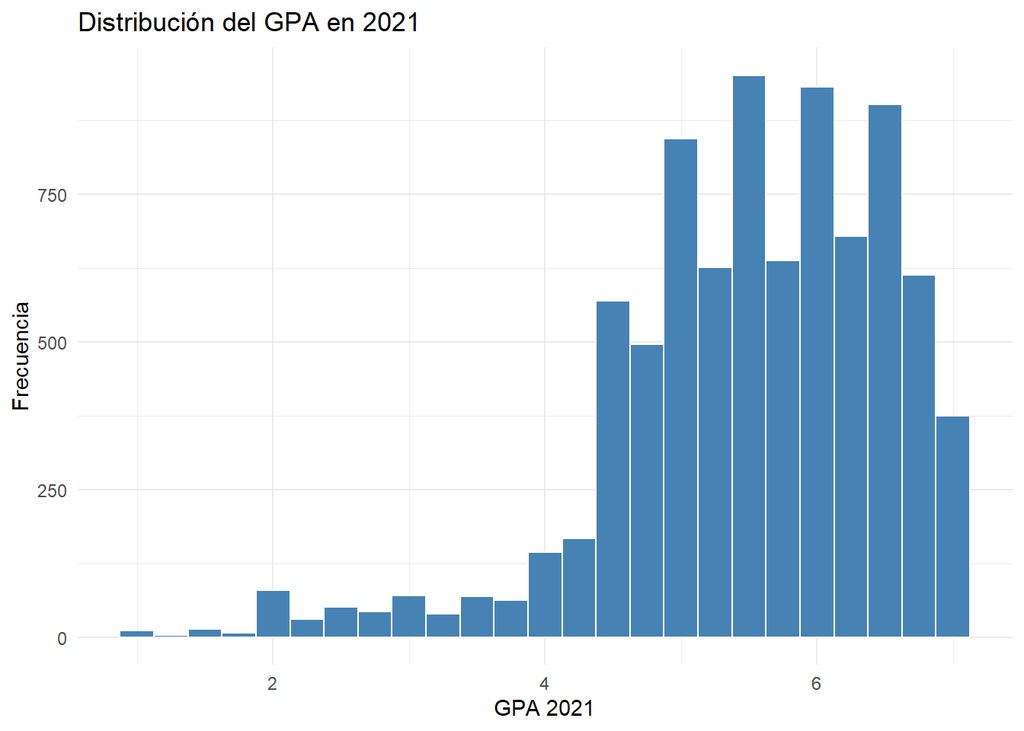

```r
# Histograma GPA
plot_gpa <- ggplot(dropout, aes(x = GPAin2021)) +
  geom_histogram(binwidth = 0.25, fill = "steelblue", color = "white") +
  labs(title = "Distribución del GPA en 2021", x = "GPA 2021", y = "Frecuencia") +
  theme_minimal()
print(plot_gpa)
```

```r
guardar_plot(plot_gpa, "histograma_gpa.png")
# Tabla de proporción
tabla_prop <- dropout %>%
  count(DroppedOutMay30Before) %>%
  mutate(prop = n / sum(n))

guardar_tabla_csv(tabla_prop, "proporcion_desercion_mayo.csv")
```

La unidad de análisis en este estudio corresponde a **cada estudiante de forma individual** que se desvinculó del sistema escolar entre abril y julio de 2022. Cada fila corresponde a un estudiante único con informaciones respecto de su trayectoria escolar, rendimiento y deserción/revinculación o graduación. Esta es la unidad de estudio adecuada tomando en cuenta que al ser un estudio de deserción escolar, el foco está en el comportamiento de los estudiantes y no en la institución o el sistema escolar en su conjunto.

*GPAin2021:* Variable que representa el promedio de notas del estudiante en el año 2021. Es una variable continua que varía entre 1 y 7.

La gráfica observada muestra una distribución asimétrica a la izquierda, con una gran concentración de estudiantes entre 5 y 6.5, y una cola hacia los valores bajos, lo que nos indica que no toda la deserción está asociada a un bajo rendimiento.

*DroppedOutMay30Before:* Variable que indica si el estudiante desertó antes del 30 de mayo de 2022.

### Pregunta b)

Generamos una tabla resumen con las variables de interés: Age, Female, AttendanceIn2021, GPAin2021, Migrant, PrioritaryStudentIn2021 y GraduatedIn2021.

```r
# Selección de variables
vars_b <- c("Age", "Female", "AttendanceIn2021", "GPAin2021",
            "Migrant", "PrioritaryStudentIn2021", "GraduatedIn2021")

datos_b <- dropout %>% select(all_of(vars_b))

# Crear tabla manual
tabla_b <- tibble(
  Variable = vars_b,
  Media = sapply(datos_b, function(x) mean(x, na.rm = TRUE)),
  Mediana = sapply(datos_b, function(x) median(x, na.rm = TRUE)),
  DesvEst = sapply(datos_b, function(x) sd(x, na.rm = TRUE)),
  P25 = sapply(datos_b, function(x) quantile(x, 0.25, na.rm = TRUE)),
  P75 = sapply(datos_b, function(x) quantile(x, 0.75, na.rm = TRUE)),
  N = sapply(datos_b, function(x) sum(!is.na(x)))
)

# Mostrar tabla
kable(tabla_b, caption = "Estadística Descriptiva General - Pregunta b")
```

Estadística Descriptiva General - Pregunta b

| Variable | Media | Mediana | DesvEst | P25 | P75 | N |
| --- | --- | --- | --- | --- | --- | --- |
| Age | 12.0543682 | 13.0 | 3.4597905 | 9.0 | 15.0 | 8516 |
| Female | 0.5305308 | 1.0 | 0.4990963 | 0.0 | 1.0 | 8516 |
| AttendanceIn2021 | 82.9432832 | 86.0 | 22.1686527 | 85.0 | 96.0 | 8516 |
| GPAin2021 | 5.5137595 | 5.6 | 1.0182276 | 4.9 | 6.3 | 8416 |
| Migrant | 0.1171912 | 0.0 | 0.3216668 | 0.0 | 0.0 | 8516 |
| PrioritaryStudentIn2021 | 0.6467825 | 1.0 | 0.4779976 | 0.0 | 1.0 | 8516 |
| GraduatedIn2021 | 0.9072334 | 1.0 | 0.2901221 | 1.0 | 1.0 | 8516 |

```r
guardar_tabla_csv(tabla_b, "tabla_pregunta_b.csv")
```

Lo que se puede observar desde los resultados contenidos en la taba es:

- La edad promedio de los estudiantes es de 12 años, con una mediana de 13, lo que indica que hay una asimetría hacia la izquierda (niños más pequeños)
- La proporción de mujeres es de aproximadamente 53%, lo que indica una distribución relativamente equitativa entre géneros.
- La asistencia promedio en 2021 fue de 82.9%, con una desviación estandar de 22 puntos porentuales, lo que muestra alta variabilidad en la asistencia. En dónde un 25% de los estudiantes tuvo asistencia igual o inferior a un 85% lo que indica que no puede descartarse la asistencia como un factor determinante en la deserción escolar, sin embargo, no pareciera ser el factor más relevante.
- El promedio académico en 2021 fue de 5.51 con una mediana de 5.6. Esto muestra una simetría negativa en la distribución de notas, lo que indica que la mayoría de los estudiantes tienen un rendimiento académico aceptable, sin embargo, hay una proporción importante de estudiantes con GPA bajo.
- La proporción de estudiantes migrantes es de aproximadamente 11.7%, lo que indica muy baja migración en la población estudiada y por tanto no es un factor que parezca relevante en la deserción escolar.
- El 65& de los estudiantes son considerados prioritarios, lo que indica que la mayoría de los estudiantes provienen de contextos vulnerables.
- Más del 90% de los estudiantes se graduaron en 2021, lo que indica que la mayoría de los estudiantes completaron su educación básica.

Respecto del tamaño muestral de las variables, todas presentan un valor de **8516** exceptuando por **GPAin2021** que tiene un tamaño muestral de **8416**. Por lo que sus valores están sujetos a un mayor margen de error al tener un tamaño muestral menor. Esta diferencia puede darse debido a estudiantes no matriculados en 2021 y por tanto con ausencia de datos o también estudiantes que no finalizaron el año escolar u otros motivos.

### Pregunta c)

Analizaremos la asimetrpia de dos variables **GPAin2021** y **AttendanceIn2021**. La media de **GPAin2021** es de 5.51, la mediana es de 5.6 y el percentil 25 es 4.9, lo que indica una asimetría negativa en la distribución de notas Para el caso de **AttendanceIn2021**, la media es de 82.9, la mediana es de 86 y el percentil 25 también es de 85; este último hecho indica que hay una proporción de estudiantes con valores de asistencia notablemente más bajos , que empujan la media habia abajo para que los valores de la mediana y el percentil 25 sean más altos que la media.

Para analizar la asimetría de las variables, generaremos primero histogramas de ambas variables.

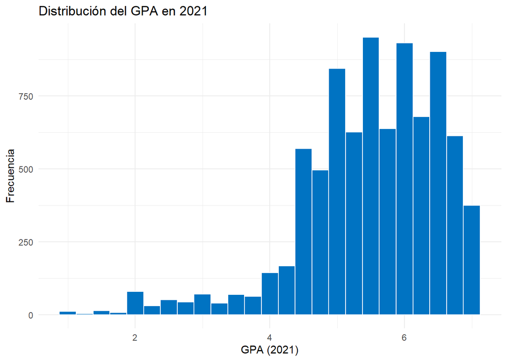

```r
# GPA
plot_hist_gpa <- ggplot(dropout, aes(x = GPAin2021)) +
  geom_histogram(binwidth = 0.25, fill = "#0073C2FF", color = "white") +
  labs(title = "Distribución del GPA en 2021", x = "GPA (2021)", y = "Frecuencia") +
  theme_minimal()
print(plot_hist_gpa)
```

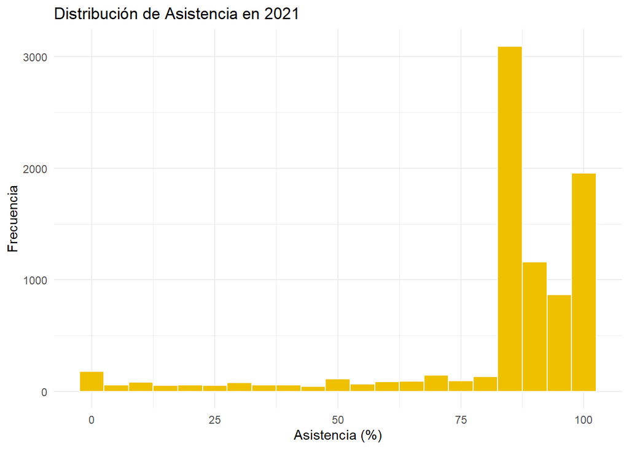

```r
guardar_plot(plot_hist_gpa, "histograma_gpa_c.png")
# Attendance
plot_hist_att <- ggplot(dropout, aes(x = AttendanceIn2021)) +
  geom_histogram(binwidth = 5, fill = "#EFC000FF", color = "white") +
  labs(title = "Distribución de Asistencia en 2021", x = "Asistencia (%)", y = "Frecuencia") +
  theme_minimal()
print(plot_hist_att)
```

```r
guardar_plot(plot_hist_att, "histograma_asistencia.png")
```

Realizamos boxplots para observar la presencia de outliers en ambas variables.

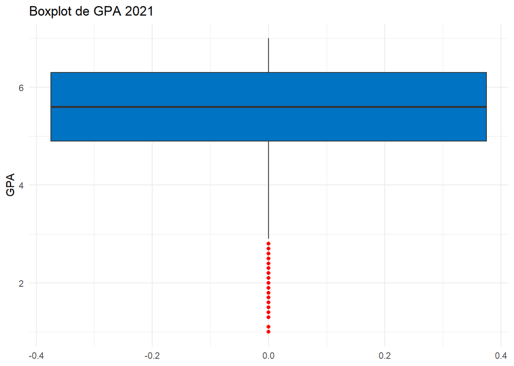

```r
# Boxplot GPA
plot_box_gpa <- ggplot(dropout, aes(y = GPAin2021)) +
  geom_boxplot(fill = "#0073C2FF", outlier.color = "red") +
  labs(title = "Boxplot de GPA 2021", y = "GPA") +
  theme_minimal()
print(plot_box_gpa)
```

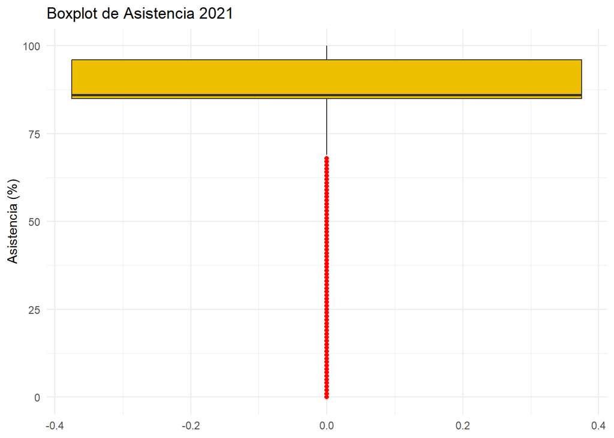

```r
guardar_plot(plot_box_gpa, "boxplot_gpa.png")
# Boxplot Attendance
plot_box_att <- ggplot(dropout, aes(y = AttendanceIn2021)) +
  geom_boxplot(fill = "#EFC000FF", outlier.color = "red") +
  labs(title = "Boxplot de Asistencia 2021", y = "Asistencia (%)") +
  theme_minimal()
print(plot_box_att)
```

```r
guardar_plot(plot_box_att, "boxplot_asistencia.png")
```

Primero para poder analizar la asimetría de las variables, generamos histogramas de ambas variables y encontramos una clara asimetría negativa para ambas variables. Luego junto con lo anterior se realizaron boxplots para observar la presencia de outliers en ambas variables. En el caso de **GPAin2021** y **AttendanceIn2021** se observa una gran cantidad de outliers, lo que puede estar afectando la media y generando la asimetría negativa.

### Pregunta d)

```r
# Variables a analizar
vars_d <- c("Age", "Female", "AttendanceIn2021", "GPAin2021",
            "Migrant", "PrioritaryStudentIn2021", "GraduatedIn2021")

# Filtrar datos por grupo
datos_0 <- dropout %>%
  filter(ListedInDropoutReport == 0) %>%
  select(all_of(vars_d))

datos_1 <- dropout %>%
  filter(ListedInDropoutReport == 1) %>%
  select(all_of(vars_d))

# Función para crear tabla descriptiva
crear_tabla <- function(df) {
  tibble(
    Variable = vars_d,
    Media = sapply(df, function(x) mean(x, na.rm = TRUE)),
    Mediana = sapply(df, function(x) median(x, na.rm = TRUE)),
    DesvEst = sapply(df, function(x) sd(x, na.rm = TRUE)),
    P25 = sapply(df, function(x) quantile(x, 0.25, na.rm = TRUE)),
    P75 = sapply(df, function(x) quantile(x, 0.75, na.rm = TRUE)),
    N = sapply(df, function(x) sum(!is.na(x)))
  )
}

# Tablas
tabla_d_0 <- crear_tabla(datos_0)
tabla_d_1 <- crear_tabla(datos_1)

# Mostrar tablas
kable(tabla_d_0, caption = "Estadísticas descriptivas para estudiantes NO listados en el reporte (ListedInDropoutReport = 0)")
```

Estadísticas descriptivas para estudiantes NO listados en el reporte (ListedInDropoutReport = 0)

| Variable | Media | Mediana | DesvEst | P25 | P75 | N |
| --- | --- | --- | --- | --- | --- | --- |
| Age | 11.8434496 | 12.0 | 3.3587242 | 9 | 15.0 | 6969 |
| Female | 0.5208782 | 1.0 | 0.4995998 | 0 | 1.0 | 6969 |
| AttendanceIn2021 | 83.3631798 | 86.0 | 21.8388767 | 85 | 96.0 | 6969 |
| GPAin2021 | 5.5586963 | 5.7 | 0.9758593 | 5 | 6.3 | 6888 |
| Migrant | 0.1231167 | 0.0 | 0.3285946 | 0 | 0.0 | 6969 |
| PrioritaryStudentIn2021 | 0.6478691 | 1.0 | 0.4776688 | 0 | 1.0 | 6969 |
| GraduatedIn2021 | 0.9190702 | 1.0 | 0.2727469 | 1 | 1.0 | 6969 |

```r
kable(tabla_d_1, caption = "Estadísticas descriptivas para estudiantes listados en el reporte (ListedInDropoutReport = 1)")
```

Estadísticas descriptivas para estudiantes listados en el reporte (ListedInDropoutReport = 1)

| Variable | Media | Mediana | DesvEst | P25 | P75 | N |
| --- | --- | --- | --- | --- | --- | --- |
| Age | 13.0045249 | 14.0 | 3.7389742 | 10.0 | 16.0 | 1547 |
| Female | 0.5740142 | 1.0 | 0.4946515 | 0.0 | 1.0 | 1547 |
| AttendanceIn2021 | 81.0517130 | 85.0 | 23.5117413 | 85.0 | 95.0 | 1547 |
| GPAin2021 | 5.3111911 | 5.4 | 1.1697616 | 4.7 | 6.2 | 1528 |
| Migrant | 0.0904977 | 0.0 | 0.2869863 | 0.0 | 0.0 | 1547 |
| PrioritaryStudentIn2021 | 0.6418875 | 1.0 | 0.4796005 | 0.0 | 1.0 | 1547 |
| GraduatedIn2021 | 0.8539108 | 1.0 | 0.3533098 | 1.0 | 1.0 | 1547 |

```r
# Exportar a archivos CSV
guardar_tabla_csv(tabla_d_0, "tabla_d_no_listados.csv")
guardar_tabla_csv(tabla_d_1, "tabla_d_listados.csv")
```

Los estudiantes listados son en promedio más grandes que los no listados (13 vs 11.84 años), con una mayor dispersión en su edad, esto no es tan extraño al pensar que muchas de las deserciones pueden nacer de desiciones de los estudiantes y que esto se da en edades más avanzadas.

El sexo también parece ser un factor relevante, se observa que la proporción de mujeres es mayor en el grupo listado (57.4% vs 52.1%), lo que podría indicar que las mujeres son más propensas a deserta, esto también a situación de vulnerabilidad social como lo puede ser un embarazo adolescente.

La asistencia promedio de los estudiantes listados es de 81.05%, mientras que la de los no listados es de 83.36%. Esto no genera gran sorpresa ya que uno podría esperar que haya un comportamiento previo a la omisión de clases que puede partir desde la inasistencia hasta el abandono total.

Finalmente tenemos diferencias en el GPA y en la cantidad de graduados, donde los estudiantes listados tienen un GPA promedio de 5.31 y una tasa de graduación de 85.4%, mientras que los no listados tienen un GPA promedio de 5.56 y una tasa de graduación de 91.9%. Nuevamente no hay gran sorpresa en los resultados observados, particularmente en la cantidad de graduados, ya que uno podría esperar que los estudiantes que desertan no logren graduarse, si genera una sorpresa la diferencia en el GPA, ya que uno podría esperar diferencias mucho más marcadas en le promedio de notas.

### Pregunta e)

```r
# Variables a evaluar
variables_e <- c("Age", "Female", "AttendanceIn2021", "GPAin2021",
                 "Migrant", "PrioritaryStudentIn2021", "GraduatedIn2021")

# Ejecutar t-test para cada variable
resultados_t <- lapply(variables_e, function(var) {
  t.test(as.formula(paste(var, "~ ListedInDropoutReport")), data = dropout)
})

# Asignar nombres
names(resultados_t) <- variables_e

# Construir tabla de resultados
tabla_t <- purrr::map_df(resultados_t, ~ tibble(
  diferencia_medias = round(diff(rev(.$estimate)), 3),
  p_value = round(.$p.value, 4)
), .id = "Variable")

# Mostrar tabla
kable(tabla_t, caption = "Diferencia de medias y p-valores (test t entre grupos)")
```

Diferencia de medias y p-valores (test t entre grupos)

| Variable | diferencia_medias | p_value |
| --- | --- | --- |
| Age | -1.161 | 0.0000 |
| Female | -0.053 | 0.0001 |
| AttendanceIn2021 | 2.311 | 0.0004 |
| GPAin2021 | 0.248 | 0.0000 |
| Migrant | 0.033 | 0.0001 |
| PrioritaryStudentIn2021 | 0.006 | 0.6570 |
| GraduatedIn2021 | 0.065 | 0.0000 |

```r
# Guardar tabla como CSV
guardar_tabla_csv(tabla_t, "tabla_t_test_diferencias.csv")
```

Finalmente podemos observar que los grupos no son equivalentes, y por tanto existe evidencia de sesgo de selección. Esto podría ser importante al momento de estimar efectos causales, ya que las diferencias en características observadas pueden influir tanto en la probabilidad de ser listado como en los resultados posteriores

### Pregunta f)

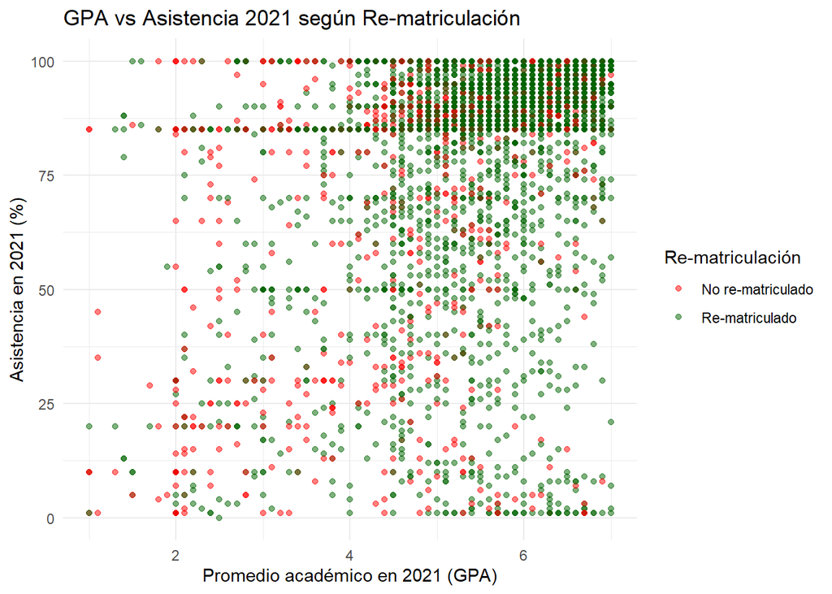

```r
# Crear gráfico de GPA vs Asistencia según re-matriculación
plot_gpa_vs_asistencia <- ggplot(dropout, aes(x = GPAin2021, y = AttendanceIn2021,
                                              color = factor(EnrolledByAug312022))) +
  geom_point(alpha = 0.5) +
  scale_color_manual(values = c("0" = "red", "1" = "darkgreen"),
                     labels = c("0" = "No re-matriculado", "1" = "Re-matriculado"),
                     name = "Re-matriculación") +
  labs(
    title = "GPA vs Asistencia 2021 según Re-matriculación",
    x = "Promedio académico en 2021 (GPA)",
    y = "Asistencia en 2021 (%)"
  ) +
  theme_minimal()

# Mostrar gráfico
print(plot_gpa_vs_asistencia)
```

```r
# Guardar gráfico como imagen PNG
guardar_plot(plot_gpa_vs_asistencia, "gpa_vs_asistencia_rematriculacion.png")
```

A simple vista se pueden observar patrones de comportamiento, tenemos una conentración importante de estudiantes re-matriculados en la zona superior derecha, con valores de GPA y asistencia relativamente altos, mientras que los no re-matriculados aparecen más dispersos y agrupados en zonas de baja asistencia y bajo rendimiento académico. Como bien se ha señalado con anterioridad, son resultados esperables inicialmente, ya que uno podría esperar que los estudiantes con bajo rendimiento y baja asistencia sean los que desertan. Sin embargo, la dispersión de los estudiantes re-matriculados podría indicar que hay otros factores que influyen en la re-matriculación, como el contexto familiar o social, que no están reflejados en las variables analizadas. La región de mayor cantidad de re-ingresos es para la zona con alta asistencia y GPA entre 5 y 7. Esto sugiere un perfil común para estudiantes para estudiantes que logran reingresar al sistema escolar, lo que podría indicar que los estudiantes con un rendimiento académico alto y una buena asistencia son más propensos a re-matricularse. La visualización hasta el momento podría ayudar a indentificar regiones de riesgo (a nivel gráfico), ya que la zona del tercer cuadrante (Asistencia baja y GPA bajo) podría ser un foco de atención para la intervención, ya que es donde se concentra la mayor parte de los estudiantes no re-matriculados.

### Pregunta g)

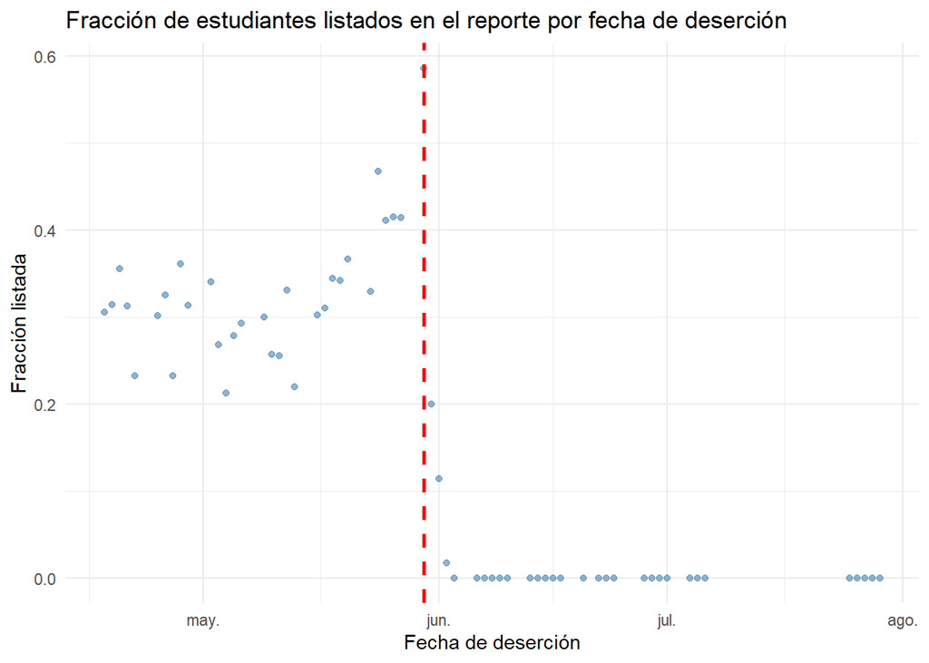

```r
# Agrupar por fecha y calcular fracción de listados
fraccion_listados <- dropout %>%
  group_by(DropoutDate) %>%
  summarise(
    n = n(),
    fraccion_listados = mean(ListedInDropoutReport, na.rm = TRUE)
  )

# Crear gráfico
plot_fraccion_fecha <- ggplot(fraccion_listados, aes(x = DropoutDate, y = fraccion_listados)) +
  geom_point(alpha = 0.6, color = "steelblue") +
  geom_vline(xintercept = as.Date("2022-05-30"), linetype = "dashed", color = "red", size = 1) +
  labs(
    title = "Fracción de estudiantes listados en el reporte por fecha de deserción",
    x = "Fecha de deserción",
    y = "Fracción listada"
  ) +
  theme_minimal()
# Mostrar gráfico
print(plot_fraccion_fecha)
```

```r
# Exportar gráfico y tabla
guardar_plot(plot_fraccion_fecha, "fraccion_listados_por_fecha.png")
guardar_tabla_csv(fraccion_listados, "fraccion_listados_por_fecha.csv")
```

La gráfica generada muestra la fracción de estudiantes que fueron listados en el reporte de deserción (ListedInDropoutReport) agrupados por fecha de deserción. La línea roja indica la fecha de corte del 30 de mayo. La discontinuidad es clara en en punto de corte, ya que antes de la fecha una fracción significativa de estudiantes desertores si fue listada, mientras que justo después de la fecha, la fracción de estudiantes cae abruptamente a valores muy cercanos al cero. Finalmente si asumimos que los estudiantes que desertaron antes y después del punto de corte con comparables en otras características (y debido al corte realizado netamente por fecha y no otros criterios subjetivos), entonces la discontinuidad puede ser usada para estimar efecto causal de ser listado y por tanto valido para el uso de un diseño de regresión discontinua.

# Causalidad y Sesgo de Selección

## Pregunta a)

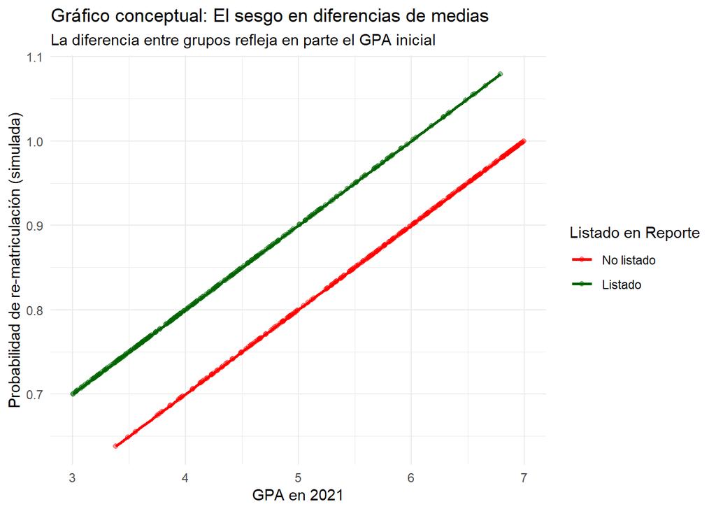

```r
set.seed(123)

# 1. Simular datos
n <- 500
GPA <- runif(n, 3, 7)  # GPA entre 3 y 7

# 2. Probabilidad de ser listado depende del GPA
prob_listado <- 1 - (GPA - 3) / 4
Listed <- rbinom(n, 1, prob_listado)

# 3. Resultados potenciales
Y0 <- 0.3 + 0.1 * GPA        # Si no listado
Y1 <- Y0 + 0.1               # Si listado

# 4. Resultado observado
Y_obs <- ifelse(Listed == 1, Y1, Y0)

# 5. Base simulada
df <- data.frame(GPA, Listed = factor(Listed), ReMatriculado = Y_obs)

# 6. Crear gráfico
plot_rubin <- ggplot(df, aes(x = GPA, y = ReMatriculado, color = Listed)) +
  geom_point(alpha = 0.4) +
  geom_smooth(method = "loess", se = FALSE) +
  scale_color_manual(
    name = "Listado en Reporte",
    labels = c("No listado", "Listado"),
    values = c("0" = "red", "1" = "darkgreen")
  ) +
  labs(
    title = "Gráfico conceptual: El sesgo en diferencias de medias",
    subtitle = "La diferencia entre grupos refleja en parte el GPA inicial",
    x = "GPA en 2021",
    y = "Probabilidad de re-matriculación (simulada)"
  ) +
  theme_minimal()

# Mostrar gráfico
print(plot_rubin)
```

```r
# Exportar gráfico
guardar_plot(plot_rubin, "grafico_rubin_simulado_sesgo.png")
```

Con el modelo de Rubin buscamos poder explicar el sesgo de selección que se presenta en el caso de los estudiantes listados y no listados. Si los grupos tratados y no tratados son diferentes en características relevantes, esa diferencia de medias no es el verdadero efectos causal y por tanto tendríamos un sesgo. En el gráfico que mostramos el valor de GPAin2021 simulado hace que se la variable tratamiento varíe y por tanto la diferencia entre los grupos no es el verdadero efecto causal, sino que refleja que el GPA era distinto entre los grupos.

## Pregunta b)

```r
set.seed(123)

# Simular datos
n <- 500
GPA <- runif(n, 3, 7)

# Probabilidad de ser listado (más bajo GPA => más chance)
prob_listado <- 1 - (GPA - 3) / 4
Listed <- rbinom(n, 1, prob_listado)

# Probabilidad de re-matricularse
prob_re_mat <- 0.2 + 0.1 * Listed + 0.15 * GPA
prob_re_mat <- pmin(pmax(prob_re_mat, 0), 1)
ReMatriculado <- rbinom(n, 1, prob_re_mat)

# Data
df <- data.frame(GPA, Listed, ReMatriculado)

# Modelo 1: sin GPA (sesgado)
modelo_sesgado <- glm(ReMatriculado ~ Listed, data = df, family = "binomial")

# Modelo 2: con GPA (ajustado)
modelo_ajustado <- glm(ReMatriculado ~ Listed + GPA, data = df, family = "binomial")

# Lista de modelos
models <- list(
  "Sin controlar por GPA" = modelo_sesgado,
  "Controlando por GPA" = modelo_ajustado
)

# Mostrar tabla comparativa en markdown
modelsummary(models,
             title = "Comparación de modelos con y sin control por GPA",
             statistic = "({std.error})",
             stars = TRUE,
             output = "markdown")
```

|  | Sin controlar por GPA | Controlando por GPA |
| --- | --- | --- |
| (Intercept) | 3.170*** | -6.850*** |
|  | (0.323) | (1.725) |
| Listed | -0.772+ | 1.437** |
|  | (0.395) | (0.530) |
| GPA |  | 2.031*** |
|  |  | (0.385) |
| Num.Obs. | 500 | 500 |
| AIC | 232.4 | 185.7 |
| BIC | 240.8 | 198.3 |
| Log.Lik. | -114.187 | -89.853 |
| F | 3.815 | 14.113 |
| RMSE | 0.24 | 0.23 |

+ p < 0.1, * p < 0.05, ** p < 0.01, *** p < 0.001

```r
# También exportar a CSV para respaldar resultados
# Convertir los modelos a tabla con coeficientes
tabla_modelos_b2 <- modelsummary(models, output = "data.frame")

# Guardar como CSV
guardar_tabla_csv(tabla_modelos_b2, "comparacion_modelos_gpa.csv")
```

Realizamos una simulación similar a la del punto anterior en donde GPA es una variable que determina la probabilidad de ser listado y también la probabilidad de re-matriculación. En esta segunda instancia comparamos dos modelos, uno que no considera la variable GPA y otro que si lo hace.

En el primer modelo (Listed = -0.772 | p = 0.051) que no considera al variable GPA y por tanto está sesgados, se sugiere que ser listado reduce la probabilidad de re-matricularse, pero eso es falso, porque en la simulación el feceto real era positivo (**+0.1**), esto se da dado que el GPA está omitido y los alumnos listados tienen menor GPA en promedio, lo que hace queel modelo asocie la variable Listed a una menor probabilidad de re-matriculación.

En el segundo modelo (Listed = 1.437 | p < 0.01 ^ GPA = 2.0315 | p < 0.001) que incorpora la variable GPA el efecto resultante de Listed es positivo y significativo reflejando el efecto real del tratamiento. Esto se da porque el modelo ahora considera la variable GPA y por tanto el efecto de Listed es positivo, ya que los estudiantes listados tienen un GPA más bajo en promedio, lo que hace que el modelo asocie la variable Listed a una mayor probabilidad de re-matriculación.

## Pregunta c)

```r
# 1. Calcular medias generales por grupo listado/no listado
medias_generales <- dropout %>%
  group_by(ListedInDropoutReport) %>%
  summarise(
    GPA = mean(GPAin2021, na.rm = TRUE),
    Asistencia = mean(AttendanceIn2021, na.rm = TRUE),
    n = n()
  )

# Mostrar en el documento
print(medias_generales)
```

```
## # A tibble: 2 × 4
##   ListedInDropoutReport   GPA Asistencia     n
##                   <dbl> <dbl>      <dbl> <int>
## 1                     0  5.56       83.4  6969
## 2                     1  5.31       81.1  1547
```

```r
# Exportar como CSV
guardar_tabla_csv(medias_generales, "medias_generales_listado.csv")
```

```r
# 2. Crear deciles de edad
dropout <- dropout %>%
  mutate(decil_edad = ntile(Age, 10))

# 3. Calcular medias de GPA y Asistencia por decil y grupo
comparacion_deciles <- dropout %>%
  group_by(decil_edad, ListedInDropoutReport) %>%
  summarise(
    GPA = mean(GPAin2021, na.rm = TRUE),
    Asistencia = mean(AttendanceIn2021, na.rm = TRUE),
    n = n()
  ) %>%
  ungroup()

# Mostrar tabla
print(comparacion_deciles)
```

```
## # A tibble: 20 × 5
##    decil_edad ListedInDropoutReport   GPA Asistencia     n
##         <int>                 <dbl> <dbl>      <dbl> <int>
##  1          1                     0  6.17       83.2   718
##  2          1                     1  6.17       84.4   134
##  3          2                     0  6.05       85.4   721
##  4          2                     1  6.04       84.8   131
##  5          3                     0  5.93       84.5   735
##  6          3                     1  5.90       84.7   117
##  7          4                     0  5.72       86.4   736
##  8          4                     1  5.77       85.0   116
##  9          5                     0  5.62       85.4   739
## 10          5                     1  5.62       83.5   113
## 11          6                     0  5.51       85.1   733
## 12          6                     1  5.53       83.3   119
## 13          7                     0  5.30       83.7   714
## 14          7                     1  5.28       82.7   137
## 15          8                     0  5.19       82.4   708
## 16          8                     1  4.88       79.0   143
## 17          9                     0  5.04       79.8   666
## 18          9                     1  4.76       77.8   185
## 19         10                     0  4.71       74.5   499
## 20         10                     1  4.67       76.2   352
```

```r
# Exportar como CSV
guardar_tabla_csv(comparacion_deciles, "comparacion_deciles_edad.csv")
```

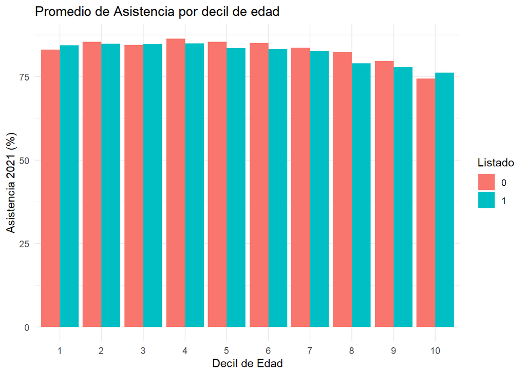

```r
# Gráfico de Asistencia por decil
plot_asistencia_decil <- ggplot(comparacion_deciles, aes(x = factor(decil_edad), y = Asistencia,
                                                         fill = factor(ListedInDropoutReport))) +
  geom_col(position = "dodge") +
  labs(
    title = "Promedio de Asistencia por decil de edad",
    x = "Decil de Edad",
    y = "Asistencia 2021 (%)",
    fill = "Listado"
  ) +
  theme_minimal()

# Mostrar y guardar
print(plot_asistencia_decil)
```

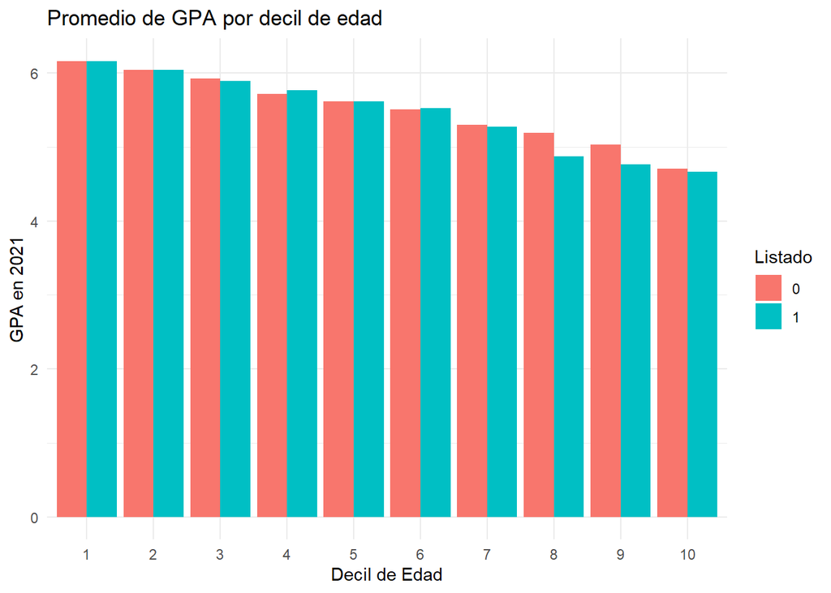

```r
guardar_plot(plot_asistencia_decil, "asistencia_por_decil.png")


# Gráfico de GPA por decil
plot_gpa_decil <- ggplot(comparacion_deciles, aes(x = factor(decil_edad), y = GPA,
                                                  fill = factor(ListedInDropoutReport))) +
  geom_col(position = "dodge") +
  labs(
    title = "Promedio de GPA por decil de edad",
    x = "Decil de Edad",
    y = "GPA en 2021",
    fill = "Listado"
  ) +
  theme_minimal()

# Mostrar y guardar
print(plot_gpa_decil)
```

```r
guardar_plot(plot_gpa_decil, "gpa_por_decil.png")
```

En la primera tabla se puede observar que en general los estudiantes listados presentan un GPA promedio de 5.31 y una asistencia promedio de 81.05% frente a un GPA promedio de 5.56 y una asistencia promedio de 83.36% para los estudiantes no listados. Esto sugiere que los estudiantes listados tienen un rendimiento académico y una asistencia inferior a la de los no listados.

## Pregunta d)

```r
# Modelo con muestra completa
modelo_completo <- glm(EnrolledByAug312022 ~ ListedInDropoutReport,
                       data = dropout, family = "binomial")

# Modelo restringido a estudiantes con asistencia ≥ 85%
modelo_alta_asistencia <- dropout %>%
  filter(AttendanceIn2021 >= 85) %>%
  glm(EnrolledByAug312022 ~ ListedInDropoutReport,
      data = ., family = "binomial")

# Lista de modelos
models_2d <- list(
  "Muestra completa" = modelo_completo,
  "Asistencia ≥ 85%" = modelo_alta_asistencia
)

# Mostrar tabla en el documento
modelsummary(models_2d,
             title = "Comparación de modelos: efecto de ser listado sobre re-matriculación",
             statistic = "({std.error})",
             stars = TRUE,
             output = "markdown")
```

|  | Muestra completa | Asistencia ≥ 85% |
| --- | --- | --- |
| (Intercept) | 1.854*** | 1.941*** |
|  | (0.035) | (0.040) |
| ListedInDropoutReport | -2.089*** | -2.111*** |
|  | (0.062) | (0.070) |
| Num.Obs. | 8516 | 7033 |
| AIC | 7655.6 | 6082.7 |
| BIC | 7669.7 | 6096.4 |
| Log.Lik. | -3825.801 | -3039.360 |
| F | 1134.012 |  |
| RMSE | 0.38 | 0.37 |

+ p < 0.1, * p < 0.05, ** p < 0.01, *** p < 0.001

```r
# Exportar tabla a CSV
tabla_models_2d <- modelsummary(models_2d, output = "data.frame")
guardar_tabla_csv(tabla_models_2d, "modelos_listado_asistencia.csv")
```

Para poder analizar la estimación restringida respecto de la estimación completo se realizaron dos regresiones para evaluar el efecto de ser listado sobre la probabilidad de re-matriculación. En la primera regresión se utilizó la muestra completa y en la segunda regresión se restringió a estudiantes con asistencia igual o superior al 85%.

Esta compración nos permite evaluar los efectos de ser listado sobre la re-matriculación en diferentes contextos, y nos ayuda a entender mejor el sesgo de selección presente en el análisis.

## Pregunta e)

```r
# Verificar NAs en variables clave del propensity score
resumen_nas <- dropout %>%
  select(ListedInDropoutReport, Age, Female, AttendanceIn2021, GPAin2021,
         Migrant, PrioritaryStudentIn2021, GraduatedIn2021) %>%
  summarise_all(~ sum(is.na(.)))

# Mostrar resumen de NAs en consola
print(resumen_nas)
```

```
## # A tibble: 1 × 8
##   ListedInDropoutReport   Age Female AttendanceIn2021 GPAin2021 Migrant
##                   <int> <int>  <int>            <int>     <int>   <int>
## 1                     0     0      0                0       100       0
## # ℹ 2 more variables: PrioritaryStudentIn2021 <int>, GraduatedIn2021 <int>
```

```r
# Guardar resumen como CSV
guardar_tabla_csv(resumen_nas, "resumen_nas_propensity.csv")

# Crear base limpia eliminando observaciones con NA
dropout_clean <- dropout %>%
  select(ListedInDropoutReport, Age, Female, AttendanceIn2021, GPAin2021,
         Migrant, PrioritaryStudentIn2021, GraduatedIn2021, EnrolledByAug312022) %>%
  drop_na()

# Exportar base limpia como respaldo
write.csv(dropout_clean, file = file.path(path_output, "dropout_clean.csv"), row.names = FALSE)
```

```r
# Fórmula del propensity score
ps_formula <- ListedInDropoutReport ~ Age + Female + AttendanceIn2021 + GPAin2021 +
  Migrant + PrioritaryStudentIn2021 + GraduatedIn2021

# Matching con método nearest neighbor y logit
match_model <- matchit(ps_formula, data = dropout_clean,
                       method = "nearest", distance = "logit")

# Base emparejada
match_data <- match.data(match_model)

# Modelo 1: con datos emparejados (matching)
modelo_matching <- glm(EnrolledByAug312022 ~ ListedInDropoutReport,
                       data = match_data, family = "binomial")

# Modelo 2: OLS con muestra limpia sin emparejar
modelo_ols <- glm(EnrolledByAug312022 ~ ListedInDropoutReport,
                  data = dropout_clean, family = "binomial")

# Tabla comparativa
models_e <- list(
  "OLS (sin matching)" = modelo_ols,
  "Matching P.Score" = modelo_matching
)

# Mostrar tabla comparativa
modelsummary(models_e,
             title = "Comparación: OLS vs Matching por Propensity Score",
             statistic = "({std.error})",
             stars = TRUE,
             output = "markdown")
```

|  | OLS (sin matching) | Matching P.Score |
| --- | --- | --- |
| (Intercept) | 1.869*** | 1.477*** |
|  | (0.035) | (0.066) |
| ListedInDropoutReport | -2.100*** | -1.709*** |
|  | (0.063) | (0.084) |
| Num.Obs. | 8416 | 3056 |
| AIC | 7521.1 | 3569.3 |
| BIC | 7535.2 | 3581.4 |
| Log.Lik. | -3758.574 | -1782.669 |
| F | 1128.856 | 418.315 |
| RMSE | 0.37 | 0.45 |

+ p < 0.1, * p < 0.05, ** p < 0.01, *** p < 0.001

```r
# Exportar tabla como CSV
tabla_models_e <- modelsummary(models_e, output = "data.frame")
guardar_tabla_csv(tabla_models_e, "comparacion_ols_vs_matching.csv")
```

Podemos observar que el modelo con matching por propensity score muestra una cantidad inferior de observaciones (n = 3056) en comparación con el modelo OLS (n = 8416).

El matching corrige parcialmente el sesgo de selección al comparar individuos con características similares, sin embargo, la persistencia del efecto negativo incluso después del emparejamiento refuerza la evidencia de que ser listado está asociado con una menor probabilidad de re-matriculación.

## Pregunta f)

```r
# Modelo con interacción: Listed x GPA
modelo_interaccion <- glm(EnrolledByAug312022 ~ ListedInDropoutReport * GPAin2021,
                          data = dropout, family = "binomial")

# Mostrar resumen en consola
summary(modelo_interaccion)
```

```
##
## Call:
## glm(formula = EnrolledByAug312022 ~ ListedInDropoutReport * GPAin2021,
##     family = "binomial", data = dropout)
##
## Coefficients:
##                                 Estimate Std. Error z value Pr(>|z|)
## (Intercept)                     -0.70359    0.17522  -4.015 5.93e-05 ***
## ListedInDropoutReport           -1.41764    0.31997  -4.431 9.40e-06 ***
## GPAin2021                        0.47720    0.03278  14.556  < 2e-16 ***
## ListedInDropoutReport:GPAin2021 -0.12409    0.05863  -2.117   0.0343 *
## ---
## Signif. codes:  0 '***' 0.001 '**' 0.01 '*' 0.05 '.' 0.1 ' ' 1
##
## (Dispersion parameter for binomial family taken to be 1)
##
##     Null deviance: 8665.8  on 8415  degrees of freedom
## Residual deviance: 7253.7  on 8412  degrees of freedom
##   (100 observations deleted due to missingness)
## AIC: 7261.7
##
## Number of Fisher Scoring iterations: 4
```

```r
# Convertir a tabla con tidy
tabla_interaccion <- tidy(modelo_interaccion)

# Exportar como CSV
guardar_tabla_csv(tabla_interaccion, "modelo_interaccion_listado_gpa.csv")
```

El modelo estimado en este caso es el

$logit(Y_i) = β0 + β1 * Listed_i + β2 * GPA_i + β3 * Listed_i * GPA_i) + ε_i$

El coeficiente negativo (**-0.124) entrega evidencia estadísticamente significativa que a mayor GPA, más negativo es el efecto de ser listado sobre la probabilidad de re-matricularse. Entonces si existe heterogeneidad en el efecto del tratamento dado que el listado es particularmente perjudicial para estudiantes con mejor GPA, lo que sugiere que las polítivas de intervención deberían considerar esta heterogeneidad al momento de diseñar estrategias de re-matriculación.

## Pregunta g)

```r
# Modelo para establecimientos municipales
modelo_municipal <- glm(EnrolledByAug312022 ~ ListedInDropoutReport,
                        data = filter(dropout, MunicipalSchool == 1),
                        family = "binomial")

# Modelo para establecimientos no municipales
modelo_no_municipal <- glm(EnrolledByAug312022 ~ ListedInDropoutReport,
                           data = filter(dropout, MunicipalSchool == 0),
                           family = "binomial")

# Lista de modelos
models_2g <- list(
  "Municipal" = modelo_municipal,
  "No Municipal" = modelo_no_municipal
)

# Mostrar tabla en markdown
modelsummary(models_2g,
             title = "Comparación: Efecto del listado según tipo de establecimiento",
             statistic = "({std.error})",
             stars = TRUE,
             output = "markdown")
```

|  | Municipal | No Municipal |
| --- | --- | --- |
| (Intercept) | 1.695*** | 2.062*** |
|  | (0.045) | (0.055) |
| ListedInDropoutReport | -2.131*** | -2.050*** |
|  | (0.083) | (0.094) |
| Num.Obs. | 4590 | 3926 |
| AIC | 4376.3 | 3238.0 |
| BIC | 4389.1 | 3250.5 |
| Log.Lik. | -2186.135 | -1616.977 |
| F | 657.426 | 470.632 |
| RMSE | 0.39 | 0.36 |

+ p < 0.1, * p < 0.05, ** p < 0.01, *** p < 0.001

```r
# Exportar tabla como CSV
tabla_models_2g <- modelsummary(models_2g, output = "data.frame")
guardar_tabla_csv(tabla_models_2g, "comparacion_listado_tipo_establecimiento.csv")
```

Para esta parte se estimaron dos modelos logísticos por separado para evaluar el efecto de ser listado sobre la probailidad de re-matricularse, uno para estudiantes de establecimientos municipales y otro para estudiantes de establecimientos no municipales.

Los resutlados sugieren que en ambos tipos de establecimientos, el efecto de ser listado es negativo y altamente significativo, sin embargo, el efecto es ligeramente más negativo en los establecimientos municipales (-2.131) en comparación con los no municipales (-2.050). Esto sufiere que la revinculación es aún menos probable para estudiantes listados en ese tipo de escuela, lo que podría estar relacionado con diferencias en capacidad institucional, recursos disponibles o acceso a programas de reinserción escolar.

Finalmente podemos decir que el efecto del tratamiento no es completamente homogéneo. Aunque es negativo en ambos casos, el impacto de estar listado es algo más severo en estudiantes de escueltas municipales, lo que sugiere estrategias de intervención diferenciadas para cada tipo de establecimiento.

## Pregunta h)

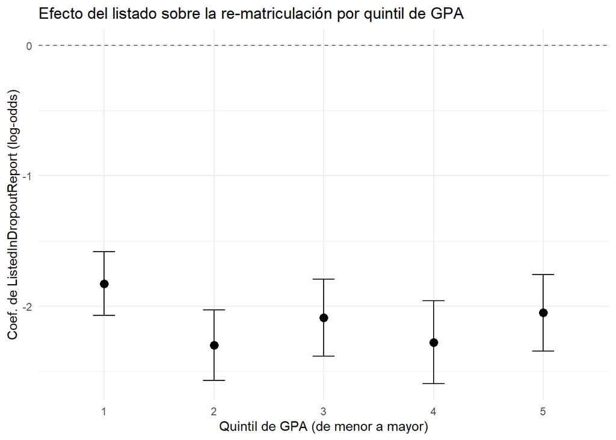

```r
# Asegurar que no haya NA en GPA y calcular quintiles
dropout_quintiles <- dropout %>%
  filter(!is.na(GPAin2021)) %>%
  mutate(gpa_quintil = ntile(GPAin2021, 5))

# Estimar modelos logísticos por quintil
resultados_quintiles <- dropout_quintiles %>%
  group_by(gpa_quintil) %>%
  group_map(~ {
    model <- glm(EnrolledByAug312022 ~ ListedInDropoutReport,
                 data = .x, family = "binomial")
    tidy(model) %>%
      filter(term == "ListedInDropoutReport") %>%
      mutate(quintil = .y$gpa_quintil)
  }) %>%
  bind_rows()

# Exportar tabla de coeficientes por quintil
guardar_tabla_csv(resultados_quintiles, "efecto_listado_por_quintil_gpa.csv")

# Crear gráfico
plot_quintiles <- ggplot(resultados_quintiles, aes(x = factor(quintil), y = estimate)) +
  geom_point(size = 3) +
  geom_errorbar(aes(ymin = estimate - 1.96 * std.error,
                    ymax = estimate + 1.96 * std.error), width = 0.2) +
  geom_hline(yintercept = 0, linetype = "dashed", color = "gray40") +
  labs(
    title = "Efecto del listado sobre la re-matriculación por quintil de GPA",
    x = "Quintil de GPA (de menor a mayor)",
    y = "Coef. de ListedInDropoutReport (log-odds)"
  ) +
  theme_minimal()

# Mostrar y guardar gráfico
print(plot_quintiles)
```

```r
guardar_plot(plot_quintiles, "efecto_listado_por_quintil_gpa.png")
```

En esta parte se estimaros regresiones logísticas separadas por quintiles de GPA para evaluar el efecto de ser listado sobre la probabilidad de re-matricularse. Los resultados muestran que el efecto del tratamiento es negativo en todos los quintiles, pero varía en magnitud, lo que sugiere que ser listado reduce la probabilidad de re-matricularse de forma consistente.

## Pregunta i)

```r
# a) Modelo con toda la muestra
modelo_i_completo <- glm(GraduatedIn2022 ~ ListedInDropoutReport,
                         data = dropout, family = "binomial")

# b) Modelo con solo estudiantes re-matriculados
modelo_i_reenrolados <- glm(GraduatedIn2022 ~ ListedInDropoutReport,
                            data = filter(dropout, EnrolledByAug312022 == 1),
                            family = "binomial")

# Lista de modelos
models_i <- list(
  "Muestra completa" = modelo_i_completo,
  "Solo re-matriculados" = modelo_i_reenrolados
)

# Mostrar resultados en markdown
modelsummary(models_i,
             title = "Comparación: efecto del listado sobre Graduación 2022",
             statistic = "({std.error})",
             stars = TRUE,
             output = "markdown")
```

|  | Muestra completa | Solo re-matriculados |
| --- | --- | --- |
| (Intercept) | 1.079*** | 1.683*** |
|  | (0.028) | (0.035) |
| ListedInDropoutReport | -1.298*** | 0.410** |
|  | (0.058) | (0.127) |
| Num.Obs. | 8516 | 6708 |
| AIC | 10024.0 | 5708.0 |
| BIC | 10038.1 | 5721.6 |
| Log.Lik. | -5009.999 | -2851.996 |
| F | 499.517 | 10.332 |
| RMSE | 0.45 | 0.36 |

+ p < 0.1, * p < 0.05, ** p < 0.01, *** p < 0.001

```r
# Exportar tabla comparativa como CSV
tabla_models_i <- modelsummary(models_i, output = "data.frame")
guardar_tabla_csv(tabla_models_i, "efecto_listado_graduacion_2022.csv")
```

En esta parte se estimaron dos modelos logísticos para evaluar el efecto de ser listado sobre la probabilidad de graduarse en 2022. El primer modelo utiliza toda la muestra y el segundo se restringe a los estudiantes que fueron re-matriculados.

Esta comparación muestra un caso claro de sesgo de selección, ya que el listado tiene un efecto negativo sobre la graduación cuando se analiza correctamente la muestra completa, y restringir el análisis solo a quienes se re-matricularon introduce un sesgo que distorsiona completamente la conclusión. En el primer modelo, el efecto de ser listado es negativo y significativo (-1.298), lo que sugiere que ser listado reduce la probabilidad de graduarse. Sin embargo, en el segundo modelo, el efecto de ser listado es positivo y significativo (0.410), lo que sugiere que, entre los estudiantes re-matriculados, ser listado está asociado con una mayor probabilidad de graduarse.

Esto confirma que condicionar en variables intermedias puede llevar a conclusiones erróneas y alterar seriamente las inferencias causales.

## Pregunta j)

```r
# Modelo IV: Dos etapas con instrumento DroppedOutMay30Before
modelo_iv <- ivreg(EnrolledByAug312022 ~ ListedInDropoutReport | DroppedOutMay30Before,
                   data = dropout)

# Modelo logístico clásico para comparar
modelo_logit <- glm(EnrolledByAug312022 ~ ListedInDropoutReport,
                    data = dropout, family = "binomial")

# Mostrar resumen del modelo IV
summary(modelo_iv)
```

```
##
## Call:
## ivreg(formula = EnrolledByAug312022 ~ ListedInDropoutReport |
##     DroppedOutMay30Before, data = dropout)
##
## Residuals:
##     Min      1Q  Median      3Q     Max
## -0.7881  0.2119  0.2119  0.2119  0.2142
##
## Coefficients:
##                        Estimate Std. Error t value Pr(>|t|)
## (Intercept)            0.788113   0.006764 116.515   <2e-16 ***
## ListedInDropoutReport -0.002310   0.028147  -0.082    0.935
## ---
## Signif. codes:  0 '***' 0.001 '**' 0.01 '*' 0.05 '.' 0.1 ' ' 1
##
## Residual standard error: 0.4086 on 8514 degrees of freedom
## Multiple R-Squared: 0.001732,    Adjusted R-squared: 0.001615
## Wald test: 0.006733 on 1 and 8514 DF,  p-value: 0.9346
```

```r
# Convertir resultados IV a tabla
tabla_modelo_iv <- tidy(modelo_iv)

# Exportar tabla como CSV
guardar_tabla_csv(tabla_modelo_iv, "modelo_iv_listado_droppedOut.csv")
```

Se estimó un modelo de dos etapas opara poder abordar posibles problemas de endogenenidad en la variable ListedInDropoutReport. En este caso, se utilizó la variable DroppedOutMay30Before como instrumento para ListedInDropoutReport.

Por tanto tenemos que el uso de variables intrumentales entrega una estimación más conservadora y robusta del efecto causal aunque con menor presición. La gran diferencia entre amvbos modelos evidencia la importancia de considerar problemas de endogeneidad, pero también alerta sobre la debilidad del instrumento utilizado, lo que podría llevar a conclusiones erróneas si no se tiene cuidado al interpretar los resultados.